# Classe 5: tests d’hipòtesi

Eudald Correig

17/6/2019

I taules!

| Test | Comanda 1 | Comanda 2 |
| --- | --- | --- |
| Chi 2 | chisq.test(x, y) |  |
| Fisher exact test | fisher.test(x, y) |  |
| Shapiro Wilk | shapiro.test(x) |  |
| Levene | var.test(x, y) | levene.test(y, group) |
| T - Student | t.test(x, y, var.equal = TRUE) | t.test(formula, data, var.equal = TRUE) |
| T - Welch | t.test(x, y) | t.test(formula, data) |
| Mann-Whitney U | wilcox.test(x, y) | wilcox.test(formula, data) |
| T - Welch aparellada | t.test(x, y, paired = TRUE) | t.test(formula, data, paired = TRUE) |
| Wilcoxon Signed Rank | wilcox.test(x, y, paired = TRUE) | wilcox.test(formula, data, paired = TRUE) |
| ANOVA | aov(formula, data) |  |
| Kruskall Wallis | kruskal.test(x, g) | kruskal.test(formula, data) |
| ANOVA mesures repetides | ez::ezANOVA(data, dv, wid) |  |
| Friedman | friedman.test(y, groups) | friedman.test(formula, data) |

# Contrastos d’hipòtesis

## Introducció

1. Volem verificar si es compleix una hipòtesis sobre un conjunt de dades.
- Hipòtesis nul·la (H$_0$):
- Hipòtesis alternativa (H$_1$):
2. Estadístic de contrast (sota la H$_0$)
3. Valor observat del estadístic de contrast.
4. Valor p: Si la H$_0$ és certa, probabilitat d’observar una diferència/ un valor igual o més extrem.

## Dades de mostra

Per mostrar els contrastos d’hipòtesi utilitzarem el següent conjunt:

```r
require(foreign)
fitxer<-"datasets/pulse2sa.sav"
dades<-read.spss(fitxer, to.data.frame = TRUE, use.value.labels=TRUE)
head(dades)
```

```
##   ID HEIGHT WEIGHT AGE GENDER SMOKES ALCOHOL EXERCISE TRT PULSE1 PULSE2
## 1  1    173     57  18   Dona     Si      No  Moderat  Si     86     88
## 2  2    179     58  19   Dona     Si      No  Moderat  No     82    150
## 3  3    167     62  18   Dona     Si      No     Gens  No     96    176
## 4  4    195     84  18   Home     Si      No     Gens  Si     71     73
## 5  5    173     64  18   Dona     Si      No   Intens  Si     90     88
## 6  6    184     74  22   Home     Si      No   Intens  No     78    141
##   YEAR
## 1   93
## 2   93
## 3   93
## 4   93
## 5   93
## 6   93
```

# Constrastar la normalitat

## Test de shapiro-wilk:

H$_0$: variable ~ distribució normal

H$_1$: variable no segueix distribució normal

La funció en R és:

```r
shapiro.test(x)
```

On x és un vector numèric.

Exemple:

```r
shapiro.test(dades$HEIGHT)
```

```
##
##  Shapiro-Wilk normality test
##
## data:  dades$HEIGHT
## W = 0.98817, p-value = 0.4705
```

## Comprovació visual

- És interessant fer gràfics per comprovar la normalitat de forma visual.
- Serveix, per exemple, per assegurar-nos d’haver fet bé el test de Shapiro.
- Hi ha principalment dos gràfics que ens ajudaran a veure la normalitat.
- Histograma: dibuixa les freqüències agrupades segons els resultats.
- Dibuixem l’histograma amb la funció hist().
- qqplot: dibuixa els quantils de la mostra en comparació amb quantils teòrics que segueixin una distribució normal.
- Dibuixem el qqplot amb la funció qqnorm() i qqline() opcionalment per afegir una línia que marca la normal.

## Comprovació visual: histograma

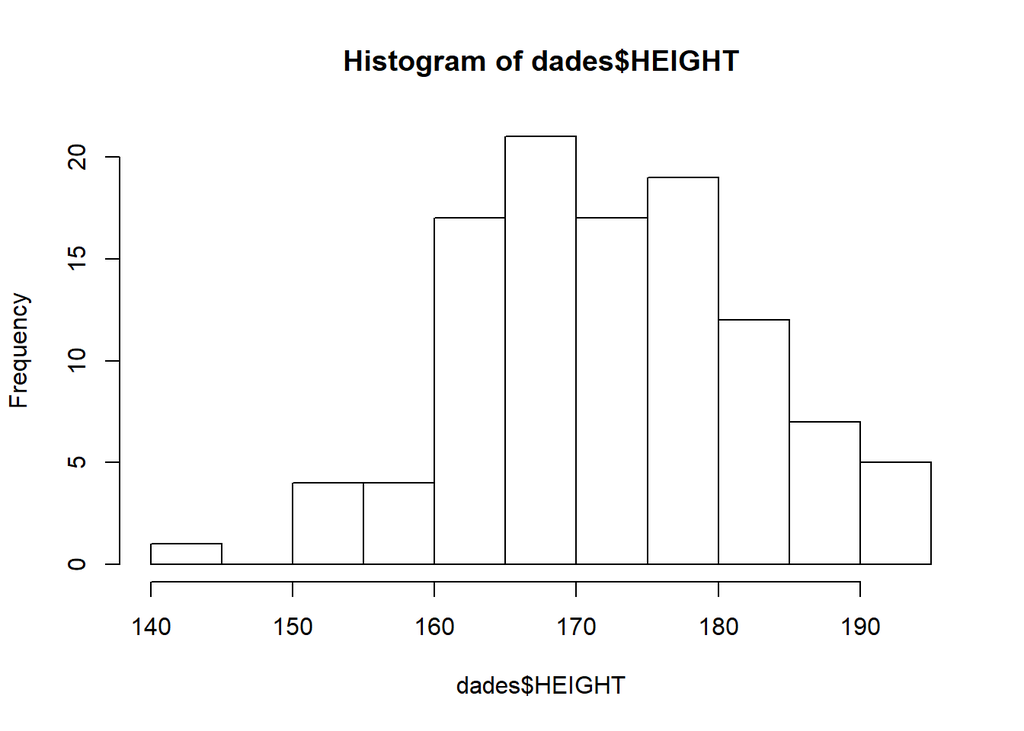

```r
hist(dades$HEIGHT)
```

## Comprovació visual: qqplot

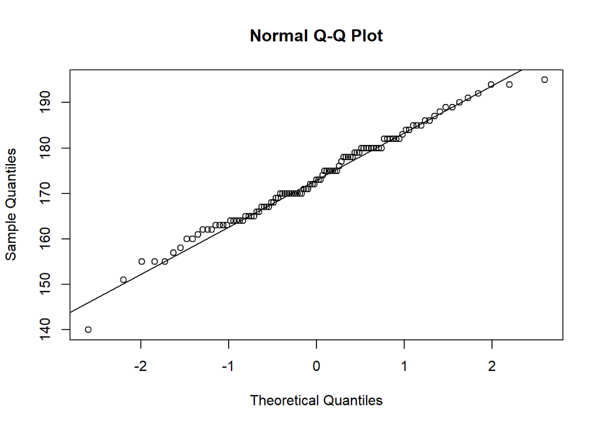

```r
qqnorm(dades$HEIGHT) # Dibuixa els punts
qqline(dades$HEIGHT) # Dibuixa una línia que marca la normal
```

# Comparació de mitjanes

## Test - T

- Respecte una mitjana ($\mu$) de referència

H$_0$: $\mu$= $\mu_0$

H$_1$: $\mu$ $\neq$ $\mu_0$

La funció en R és:

```r
t.test(x,          #  vector numèric
       y = NULL,   #  segon vector numèric, en cas de que en vulguem comparar 2
       alternative = c("two.sided", "less", "greater"), #  T d'Student bivariada o
       # univariada per l'esquerra o per la dreta
       mu = 0,     #  mitjana real, en cas de que vulguem comparar un vector x
       # amb una mitjana donada
       paired = FALSE, #  dades aparellades
       var.equal = FALSE, #  homogeneïtat de variàncies (per defecte considera que
       # les variàncies NO són homogències i fa el test de Welch)
       conf.level = 0.95, #  nivell de confiança
       ... #  altres arguments
       )
```

## Comparació de mitjanes

També es pot donar en forma de funció:

```r
t.test(x ~ y ,  #  x és un vector numèric i y categòric
       data, #  el dataframe del qual traiem les dades
       ... #  els mateixos arguments que abans
       )
```

Exemple:

- Comoparar un conjunt amb una mitjana poblacional coneguda.

```r
t.test(dades$WEIGHT, mu=70)
```

```
##
##  One Sample t-test
##
## data:  dades$WEIGHT
## t = -2.2582, df = 106, p-value = 0.02598
## alternative hypothesis: true mean is not equal to 70
## 95 percent confidence interval:
##  63.90108 69.60360
## sample estimates:
## mean of x
##  66.75234
```

## Interval de confiança

- La funció t.test, així com les que veurem a continuació, també ens donen l’interval de confiança.
- En l’exmeple anterior amb una confiança del 95% podem dir que la mitjana es troba entre 63.9 i 69.6.
- Veiem que correspon amb la p, ja que el 70 no està dins l’interval i per tant la mitjana és significativamet diferent a aquest valor.
- En els propers exemples fixeu-vos que sempre rebem un interval de confiança d’allò que estem analitzant.

Exemple:

Test-t: comparació de dues mitjanes amb variàncies heterogènies

H$_0$: $\mu$= $\mu_0$ H$_0$: $\mu$$\leq$ $\mu_0$

H$_1$: $\mu$ $\neq$ $\mu_0$ H$_1$: $\mu$ > $\mu_0$

```r
t.test(WEIGHT ~ TRT, dades)
```

```
##
##  Welch Two Sample t-test
##
## data:  WEIGHT by TRT
## t = 0.25863, df = 96.474, p-value = 0.7965
## alternative hypothesis: true difference in means is not equal to 0
## 95 percent confidence interval:
##  -5.028677  6.535487
## sample estimates:
## mean in group No mean in group Si
##         67.18889         66.43548
```

Exemple:

Test-t: comaparació de dues mitjanes amb variàncies homogenies

H$_0$: $\mu$= $\mu_0$ H$_0$: $\mu$$\leq$ $\mu_0$

H$_1$: $\mu$ $\neq$ $\mu_0$ H$_1$: $\mu$ > $\mu_0$

```r
t.test(HEIGHT~TRT, dades, var.equal=TRUE)
```

```
##
##  Two Sample t-test
##
## data:  HEIGHT by TRT
## t = 0.072909, df = 105, p-value = 0.942
## alternative hypothesis: true difference in means is not equal to 0
## 95 percent confidence interval:
##  -3.821415  4.113171
## sample estimates:
## mean in group No mean in group Si
##         173.3556         173.2097
```

Dades aparellades:

H$_0$: $\mu_1$ - $\mu_2$ = 0

H$_1$: $\mu_2$ - $\mu_2$ $\neq$ 0

```r
t.test(dades$PULSE1,dades$PULSE2,paired=TRUE) #dades aparellades
```

```
##
##  Paired t-test
##
## data:  dades$PULSE1 and dades$PULSE2
## t = -7.3572, df = 106, p-value = 4.175e-11
## alternative hypothesis: true difference in means is not equal to 0
## 95 percent confidence interval:
##  -26.71835 -15.37510
## sample estimates:
## mean of the differences
##               -21.04673
```

# Comparació de variàncies

H$_0$: $\sigma_1$ / $\sigma_2$ =1

H$_1$: $\sigma_1$/ $\sigma_2$ $\neq$ 1

```r
var.test(x, y, #  els dos vectors a comparar
         ratio = 1, #  valor esperat per l'hipòtesi 0 de la relació entre variàncies
         alternative = c("two.sided", "less", "greater"), #  bivariat o univariat
         conf.level = 0.95, #  nivell de confiança
         ... #  altres arguments
         )
```

Exemple:

```r
var.test(WEIGHT~TRT, dades)
```

```
##
##  F test to compare two variances
##
## data:  WEIGHT by TRT
## F = 0.94551, num df = 44, denom df = 61, p-value = 0.8541
## alternative hypothesis: true ratio of variances is not equal to 1
## 95 percent confidence interval:
##  0.5499249 1.6670453
## sample estimates:
## ratio of variances
##          0.9455104
```

# Comparació de medianes (no paramètric)

## Wilcoxon-Mann-Whitney test

H$_0$: Mediana$_1$ = Mediana$_2$

H$_1$: Mediana$_1$ $\neq$ Mediana$_2$

La funció en R és:

```r
wilcox.test(x,          #  vector numèric
            y = NULL,   #  segon vector numèric, en cas de que en vulguem comparar 2
            alternative = c("two.sided", "less", "greater"), #  T d'Student bivariada o univariada per l'esquerra o per la dreta
            mu = 0,     #  mitjana real, en cas de que vulguem comparar un vector x amb una mitjana donada
           paired = FALSE, #  dades aparellades
           var.equal = FALSE, #  homogeneïtat de variàncies (per defecte fa considera que les variàncies NO són homogències i fa el test de Welch)
           conf.level = 0.95, #  nivell de confiança
           ... #  altres arguments
           )
```

També es pot donar en forma de funció:

```r
wilcox.test(x ~ y ,          #  x és un vector numèric i y categòric
            data, #  el dataframe del qual traiem les dades
            ... #  els mateixos arguments que abans
            )
```

Exemple

```r
wilcox.test(PULSE1~TRT,data=dades)
```

```
##
##  Wilcoxon rank sum test with continuity correction
##
## data:  PULSE1 by TRT
## W = 1366, p-value = 0.8571
## alternative hypothesis: true location shift is not equal to 0
```

Dades aparellades

y=x1-x2

H$_0$: Mediana$_y$ =0

H$_1$: Mediana$_y$ $\neq$ 0

```r
wilcox.test(dades$PULSE1, dades$PULSE2, paired=TRUE)
```

```
##
##  Wilcoxon signed rank test with continuity correction
##
## data:  dades$PULSE1 and dades$PULSE2
## V = 971, p-value = 1.486e-07
## alternative hypothesis: true location shift is not equal to 0
```

# Taules de contingència

## Chi quadrat

H$_0$: Variables independents

H$_1$:Variables no independents

Per comparar dues variables categòriques fem servir el test de Chi^2, que en R és:

```r
chisq.test(x, #  vector 1 a comparar
           y = NULL, #  vector 2 a comparar
           simulate.p.value = FALSE, #  simular el valor p,
           # s'utilitza en mostres petites
           ... #  altres arguments
           )
```

Exemple:

```r
chisq.test(dades$SMOKES,dades$TRT)
```

```
##
##  Pearson's Chi-squared test with Yates' continuity correction
##
## data:  dades$SMOKES and dades$TRT
## X-squared = 0.52734, df = 1, p-value = 0.4677
```

Test exacte de Fisher en R:

```r
fisher.test(x, y = NULL, #  els dos vectors categòrics a comparar
            alternative = "two.sided", #  bivariat o univariat
            conf.int = TRUE,  #  volem que mostri els intervals de confiança?
            conf.level = 0.95,   #  nivell de confiança
            simulate.p.value = FALSE, #  simular el valor p, usat en mostres petites
            ... #  altres arguments
            )
```

Exemple:

```r
fisher.test(dades$SMOKES,dades$TRT)
```

```
##
##  Fisher's Exact Test for Count Data
##
## data:  dades$SMOKES and dades$TRT
## p-value = 0.351
## alternative hypothesis: true odds ratio is not equal to 1
## 95 percent confidence interval:
##  0.07815957 2.18123509
## sample estimates:
## odds ratio
##  0.4852291
```

## Exemples:

Anem a veure com s’utilitzen. Seguim amb el fitxer de malalties del fetge.

Quines dades teníem?

```r
liver = read.csv('datasets/indian_liver_patient.csv')
head(liver)
```

```
##   Age Gender Total_Bilirubin Direct_Bilirubin Alkaline_Phosphotase
## 1  65 Female             0.7              0.1                  187
## 2  62   Male            10.9              5.5                  699
## 3  62   Male             7.3              4.1                  490
## 4  58   Male             1.0              0.4                  182
## 5  72   Male             3.9              2.0                  195
## 6  46   Male             1.8              0.7                  208
##   Alamine_Aminotransferase Aspartate_Aminotransferase Total_Protiens
## 1                       16                         18            6.8
## 2                       64                        100            7.5
## 3                       60                         68            7.0
## 4                       14                         20            6.8
## 5                       27                         59            7.3
## 6                       19                         14            7.6
##   Albumin Albumin_and_Globulin_Ratio Dataset
## 1     3.3                       0.90       1
## 2     3.2                       0.74       1
## 3     3.3                       0.89       1
## 4     3.4                       1.00       1
## 5     2.4                       0.40       1
## 6     4.4                       1.30       1
```

```r
str(liver)
```

```
## 'data.frame':    583 obs. of  11 variables:
##  $ Age                       : int  65 62 62 58 72 46 26 29 17 55 ...
##  $ Gender                    : Factor w/ 2 levels "Female","Male": 1 2 2 2 2 2 1 1 2 2 ...
##  $ Total_Bilirubin           : num  0.7 10.9 7.3 1 3.9 1.8 0.9 0.9 0.9 0.7 ...
##  $ Direct_Bilirubin          : num  0.1 5.5 4.1 0.4 2 0.7 0.2 0.3 0.3 0.2 ...
##  $ Alkaline_Phosphotase      : int  187 699 490 182 195 208 154 202 202 290 ...
##  $ Alamine_Aminotransferase  : int  16 64 60 14 27 19 16 14 22 53 ...
##  $ Aspartate_Aminotransferase: int  18 100 68 20 59 14 12 11 19 58 ...
##  $ Total_Protiens            : num  6.8 7.5 7 6.8 7.3 7.6 7 6.7 7.4 6.8 ...
##  $ Albumin                   : num  3.3 3.2 3.3 3.4 2.4 4.4 3.5 3.6 4.1 3.4 ...
##  $ Albumin_and_Globulin_Ratio: num  0.9 0.74 0.89 1 0.4 1.3 1 1.1 1.2 1 ...
##  $ Dataset                   : int  1 1 1 1 1 1 1 1 2 1 ...
```

```r
liver$Dataset = as.factor(liver$Dataset)
```

Primer mirem si segueix una distribució normal:

```r
shapiro.test(liver$Total_Protiens)
```

```
##
##  Shapiro-Wilk normality test
##
## data:  liver$Total_Protiens
## W = 0.99217, p-value = 0.003702
```

No té una distribució normal, per tant hem de fer una U de Mann - Whitney:

```r
wilcox.test(Total_Protiens~Gender, data=liver)
```

```
##
##  Wilcoxon rank sum test with continuity correction
##
## data:  Total_Protiens by Gender
## W = 35138, p-value = 0.02832
## alternative hypothesis: true location shift is not equal to 0
```

Això és veritat?

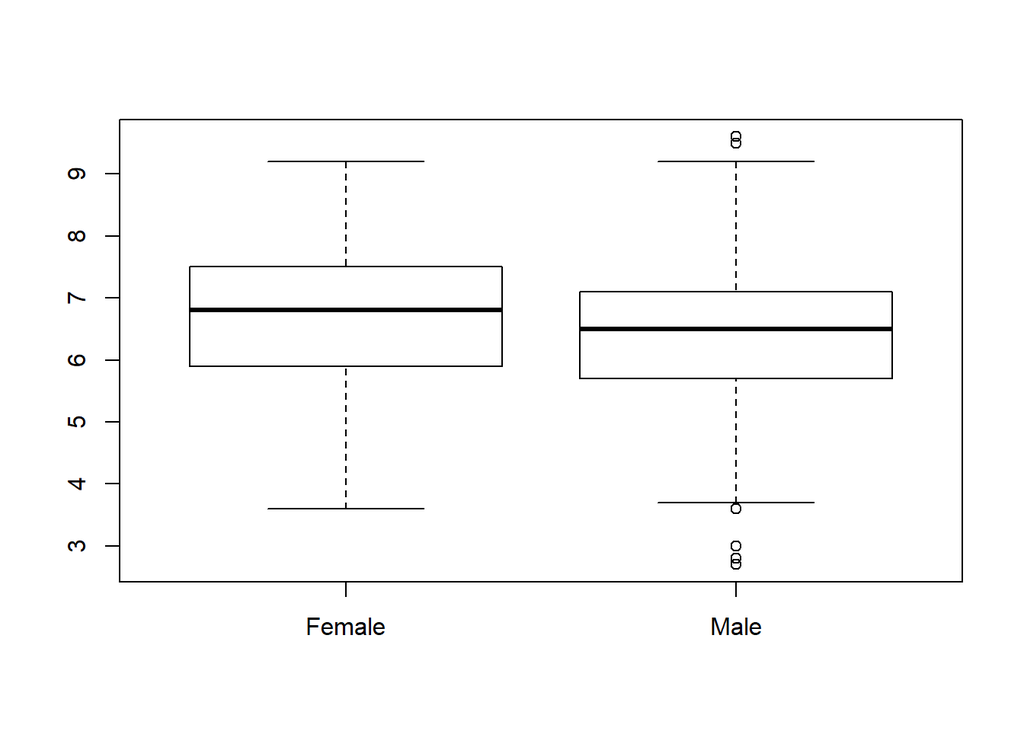

```r
plot(liver$Gender,liver$Total_Protiens)
```

Visualment sembla que potser sí, tot i que no està del tot clar.

Què passa si assumim normalitat?

```r
t.test(Total_Protiens~Gender, data=liver)
```

```
##
##  Welch Two Sample t-test
##
## data:  Total_Protiens by Gender
## t = 2.0878, df = 226.51, p-value = 0.03793
## alternative hypothesis: true difference in means is not equal to 0
## 95 percent confidence interval:
##  0.0126510 0.4377019
## sample estimates:
## mean in group Female   mean in group Male
##             6.653521             6.428345
```

Gairebé el mateix!

Provem amb una altra variable:

```r
wilcox.test(Albumin_and_Globulin_Ratio~Gender, data=liver)
```

```
##
##  Wilcoxon rank sum test with continuity correction
##
## data:  Albumin_and_Globulin_Ratio by Gender
## W = 31090, p-value = 0.8337
## alternative hypothesis: true location shift is not equal to 0
```

A veure?

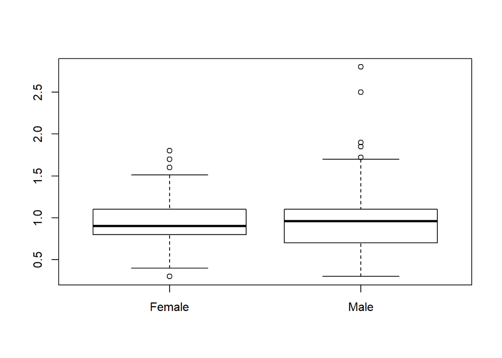

```r
plot(liver$Gender,liver$Albumin_and_Globulin_Ratio)
```

Ara volem veure si estadísticament la malaltia afecta més a homes o a dones:

```r
table(liver$Gender, liver$Dataset)
```

```
##
##            1   2
##   Female  92  50
##   Male   324 117
```

```r
chisq.test(liver$Gender, liver$Dataset)
```

```
##
##  Pearson's Chi-squared test with Yates' continuity correction
##
## data:  liver$Gender and liver$Dataset
## X-squared = 3.5466, df = 1, p-value = 0.05967
```

Justet però sembla que no!

## Correlacions

I les Albumines i els Total_Protiens estan correlacionats?

```r
cor.test(liver$Albumin, liver$Total_Protiens) # per més info ?cor.test
```

```
##
##  Pearson's product-moment correlation
##
## data:  liver$Albumin and liver$Total_Protiens
## t = 30.448, df = 581, p-value < 2.2e-16
## alternative hypothesis: true correlation is not equal to 0
## 95 percent confidence interval:
##  0.7506414 0.8134654
## sample estimates:
##       cor
## 0.7840533
```

Clarament sí! Anem a veure-ho:

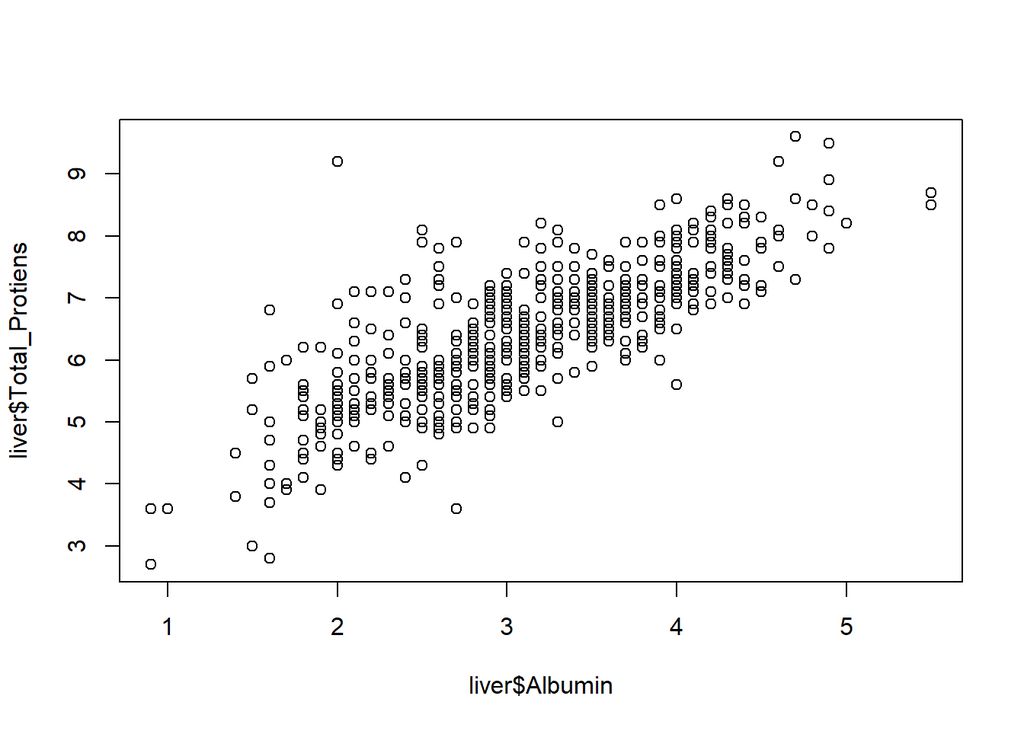

```r
plot(liver$Albumin, liver$Total_Protiens)
```

```r
#require(GGally)
#ggpairs(liver)
```

```r
liver$Total_Bilirubin=log(liver$Total_Bilirubin) # d'una en una

# o totes a l'hora:
for (i in 4:7){ # iterem sobre els números de columna
  liver[,i] = log(liver[,i]) # convertim la columna a log i sobreescrivim l'antiga
}
```